# Group 17 Team Project

IS5126 Hands-on with Applied Analytics - Team 17

Aniket Udaykumar

Niranjana Anand Unnithan

Reshma Vijay Jawale

Varsha Singh

Vidhu Verma

April 25th, 2022

## Preparation

```r
library(dplyr)
require(foreign)
require(ggplot2)
require(MASS)
require(Hmisc)
require(reshape2)
library(datasets)
library(caret)
library(pROC)

library(AER)
library(plm)
library(stargazer)
library(lattice)

library(GGally)
library(standardize)

library(tidyverse)
library(factoextra)

library("lmtest")
library("sandwich")
library("nnet")

library(Matrix)
library(MASS)
library(brant)
```

## Load data

```r
#read games dataset
games_stat = read.csv(file = 'games_stats_analysis.csv', header= TRUE)
head(games_stat)
```

```
##   X                             name steam_appid required_age is_free
## 1 0                           Dota 2         570            0       1
## 2 1 Counter-Strike: Global Offensive         730            0       1
## 3 2              PUBG: BATTLEGROUNDS      578080            0       1
## 4 3                        New World     1063730            0       0
## 5 4                  Team Fortress 2         440            0       1
## 6 5                         Unturned      304930            0       1
##   controller_support average_forever initialprice Window_platform Mac_platform
## 1                  0           35483         0.00               1            1
## 2                  1           28940         0.00               1            1
## 3                  0           21824         0.00               1            0
## 4                  0            9088        39.99               1            0
## 5                  0            9470         0.00               1            1
## 6                  0            4282         0.00               1            1
##   Linux_platform youtube_view_count youtube_comment_count Total_owners
```

[output cut: 69 more lines]

```r
# Column names of dataset
colnames(games_stat)
```

```
##  [1] "X"                           "name"
##  [3] "steam_appid"                 "required_age"
##  [5] "is_free"                     "controller_support"
##  [7] "average_forever"             "initialprice"
##  [9] "Window_platform"             "Mac_platform"
## [11] "Linux_platform"              "youtube_view_count"
## [13] "youtube_comment_count"       "Total_owners"
## [15] "total_owner_cat"             "recommendation"
## [17] "age"                         "total_ratings"
## [19] "overall_positive_rating"     "languages_supported"
## [21] "categories_count"            "genre_count"
## [23] "genre_accounting"            "genre_action"
## [25] "genre_adventure"             "genre_animation___modeling"
## [27] "genre_audio_production"      "genre_casual"
## [29] "genre_design___illustration" "genre_education"
## [31] "genre_free_to_play"          "genre_game_development"
## [33] "genre_gore"                  "genre_indie"
## [35] "genre_massively_multiplayer" "genre_movie"
## [37] "genre_nudity"                "genre_photo_editing"
## [39] "genre_racing"                "genre_rpg"
## [41] "genre_sexual_content"        "genre_simulation"
## [43] "genre_software_training"     "genre_sports"
## [45] "genre_strategy"              "genre_utilities"
## [47] "genre_violent"               "genre_web_publishing"
## [49] "custom_user_score"
```

# Linear Regression

In the section, we perform linear regression on the steam video game dataset to identify the factors that contributes to increase in sale/total owners of game.

```r
games_stat_t <- games_stat %>%
  rename( user_age=required_age, lang = languages_supported, cat_count = categories_count, action = genre_action, anime = genre_animation___modeling, game_dev= genre_game_development ,multiP=  genre_massively_multiplayer, sexual = genre_sexual_content,sports= genre_sports, violent =genre_violent, mac=Mac_platform,win=Window_platform,race =  genre_racing,  free=genre_free_to_play, adventure=genre_adventure, linux=Linux_platform, design =genre_design___illustration,casual =  genre_casual, indie=genre_indie, utilities =genre_utilities,edu =genre_education, gore =genre_gore, movie =genre_movie,simulate=genre_simulation, strategy =genre_strategy, web_publish =genre_web_publishing, rating =total_ratings)



game_reg_linear <-
 games_stat_t %>% dplyr::select(Total_owners,lang, anime, design,game_dev, multiP, sexual, sports, violent, action, race, adventure, casual,free,mac,win,  linux,cat_count, genre_count, user_age, age, custom_user_score, is_free, initialprice, controller_support,indie, rating, web_publish, strategy, simulate, movie, gore, edu, utilities)
```

```r
str(game_reg_linear)
```

```
## 'data.frame':    8729 obs. of  34 variables:
##  $ Total_owners      : int  150000000 75000000 75000000 75000000 75000000 35000000 35000000 35000000 35000000 35000000 ...
##  $ lang              : int  28 28 17 8 26 1 13 28 14 9 ...
##  $ anime             : int  0 0 0 0 0 0 0 0 0 0 ...
##  $ design            : int  0 0 0 0 0 0 0 0 0 0 ...
##  $ game_dev          : int  0 0 0 0 0 0 0 0 0 0 ...
##  $ multiP            : int  0 0 1 1 0 0 0 0 0 0 ...
##  $ sexual            : int  0 0 0 0 0 0 0 0 0 0 ...
##  $ sports            : int  0 0 0 0 0 0 0 0 0 0 ...
##  $ violent           : int  0 0 0 0 0 0 0 0 0 0 ...
##  $ action            : int  1 1 1 1 1 1 1 1 1 1 ...
##  $ race              : int  0 0 0 0 0 0 0 0 0 0 ...
##  $ adventure         : int  0 0 1 1 0 1 1 0 0 1 ...
##  $ casual            : int  0 0 0 0 0 1 0 0 0 0 ...
##  $ free              : int  1 1 1 0 1 1 0 0 1 0 ...
```

[output cut: 20 more lines]

```r
#running a simple linear regression using Ordinary Least Square (OLS).
linear_model = lm(Total_owners~., data=game_reg_linear)

## display regression output
summary(linear_model)
```

```
##
## Call:
## lm(formula = Total_owners ~ ., data = game_reg_linear)
##
## Residuals:
##       Min        1Q    Median        3Q       Max
## -79480314   -447896   -135256    183107 106519158
##
## Coefficients:
##                      Estimate Std. Error t value Pr(>|t|)
## (Intercept)        -1.381e+06  1.265e+06  -1.092  0.27497
## lang                4.187e+04  4.615e+03   9.073  < 2e-16 ***
## anime               2.571e+04  4.743e+05   0.054  0.95678
## design             -8.487e+04  4.832e+05  -0.176  0.86056
## game_dev           -2.060e+05  7.493e+05  -0.275  0.78339
## multiP              2.115e+05  1.312e+05   1.611  0.10711
## sexual             -3.260e+05  7.910e+05  -0.412  0.68020
## sports             -1.607e+05  1.344e+05  -1.195  0.23199
## violent            -2.723e+05  4.298e+05  -0.634  0.52636
## action              1.307e+05  7.550e+04   1.731  0.08353 .
## race               -3.878e+05  1.374e+05  -2.823  0.00476 **
## adventure          -3.730e+04  8.203e+04  -0.455  0.64935
## casual             -2.051e+05  7.760e+04  -2.643  0.00822 **
## free                1.792e+05  1.259e+05   1.423  0.15468
## mac                -1.527e+04  6.432e+04  -0.237  0.81234
## win                 3.519e+05  1.255e+06   0.280  0.77925
## linux               1.664e+05  7.134e+04   2.333  0.01969 *
## cat_count           6.612e+04  8.546e+03   7.737 1.13e-14 ***
## genre_count         1.016e+05  5.724e+04   1.775  0.07587 .
## user_age            5.637e+04  1.034e+04   5.451 5.13e-08 ***
## age                 7.322e+04  7.981e+03   9.175  < 2e-16 ***
## custom_user_score   4.860e+04  1.688e+04   2.880  0.00399 **
## is_free             3.178e+05  1.057e+05   3.007  0.00265 **
## initialprice        1.230e+03  2.484e+03   0.495  0.62063
## controller_support -1.957e+05  6.070e+04  -3.224  0.00127 **
## indie              -3.400e+05  7.973e+04  -4.265 2.02e-05 ***
## rating              2.407e+01  2.847e-01  84.539  < 2e-16 ***
## web_publish        -3.463e+05  5.760e+05  -0.601  0.54772
## strategy           -1.909e+05  8.475e+04  -2.252  0.02434 *
## simulate           -2.795e+04  8.189e+04  -0.341  0.73288
## movie              -1.652e+06  2.179e+06  -0.758  0.44819
## gore               -4.709e+04  5.255e+05  -0.090  0.92859
## edu                -3.314e+05  7.302e+05  -0.454  0.64996
## utilities          -9.573e+04  2.935e+05  -0.326  0.74431
## ---
## Signif. codes:  0 '***' 0.001 '**' 0.01 '*' 0.05 '.' 0.1 ' ' 1
##
## Residual standard error: 2167000 on 8694 degrees of freedom
##   (1 observation deleted due to missingness)
## Multiple R-squared:  0.4999, Adjusted R-squared:  0.498
## F-statistic: 263.3 on 33 and 8694 DF,  p-value: < 2.2e-16
```

1. Mean-Zero Error
2. Uncorrelated Error
3. No Perfect Multicollinearity
4. Homoskedasticity
5. Normal Error

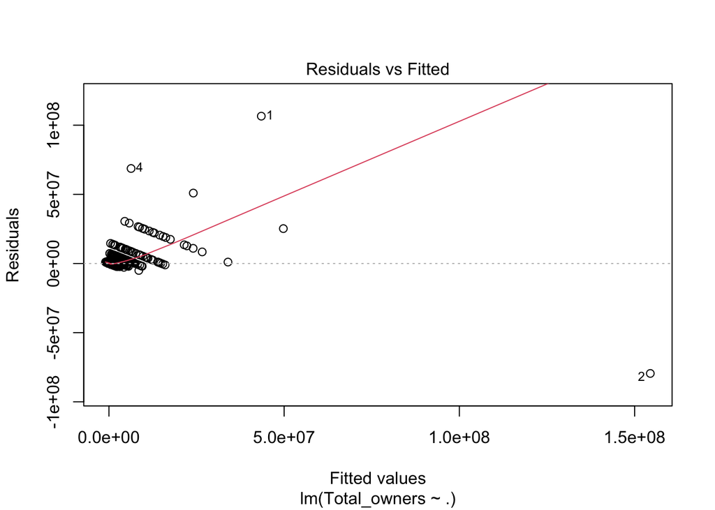

```r
#Plotting the Residual and Q-Q plots.

# Residual vs fitted plot
plot(linear_model, 1)
```

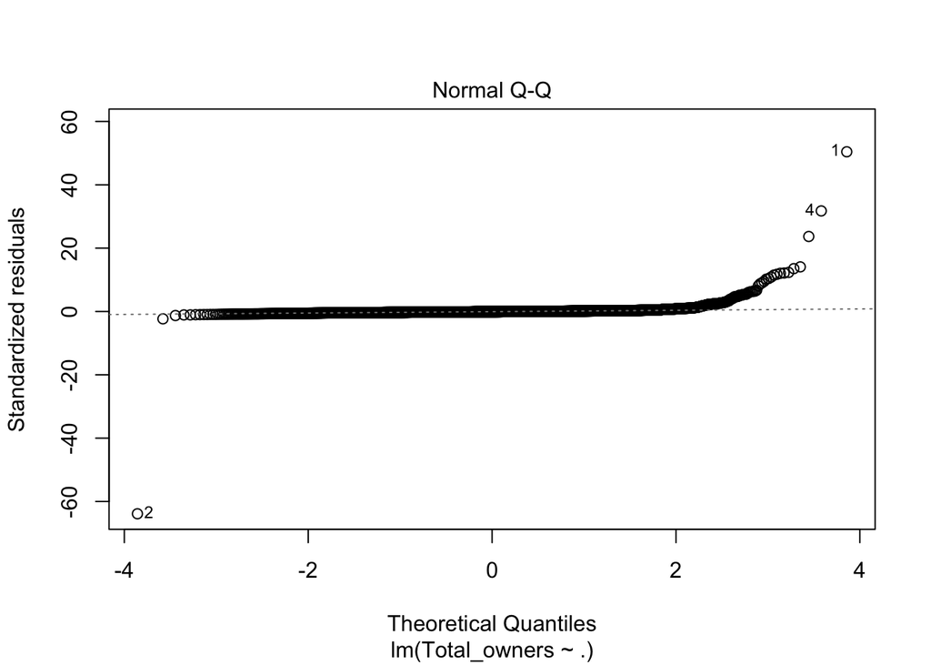

```r
# Residual Q-Q plot
plot(linear_model, 2)
```

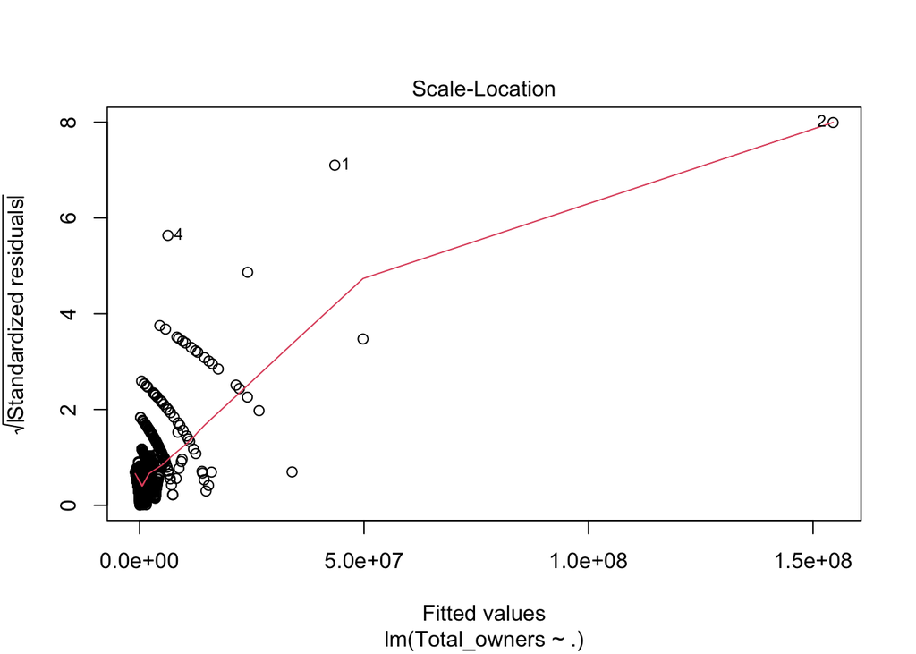

```r
plot(linear_model, 3)
```

```r
games_stat_t <- games_stat %>%
  rename(owner_cat =total_owner_cat, user_age=required_age, lang = languages_supported, cat_count = categories_count, action = genre_action, anime = genre_animation___modeling, game_dev= genre_game_development ,multiP=  genre_massively_multiplayer, sexual = genre_sexual_content,sports= genre_sports, violent =genre_violent, mac=Mac_platform,win=Window_platform,race =  genre_racing,  free=genre_free_to_play, adventure=genre_adventure, linux=Linux_platform, design =genre_design___illustration,casual =  genre_casual, indie=genre_indie)



game_regression <-
 games_stat_t %>% dplyr::select(owner_cat,lang, anime, design,game_dev, multiP, sexual, sports, violent, action, race, adventure, casual,free,mac,win,  linux,cat_count, genre_count, user_age, age, custom_user_score, is_free, initialprice, controller_support,indie)
```

```r
str(game_regression)
```

```
## 'data.frame':    8729 obs. of  26 variables:
##  $ owner_cat         : int  2 2 2 2 2 2 2 2 2 2 ...
##  $ lang              : int  28 28 17 8 26 1 13 28 14 9 ...
##  $ anime             : int  0 0 0 0 0 0 0 0 0 0 ...
##  $ design            : int  0 0 0 0 0 0 0 0 0 0 ...
##  $ game_dev          : int  0 0 0 0 0 0 0 0 0 0 ...
##  $ multiP            : int  0 0 1 1 0 0 0 0 0 0 ...
##  $ sexual            : int  0 0 0 0 0 0 0 0 0 0 ...
##  $ sports            : int  0 0 0 0 0 0 0 0 0 0 ...
##  $ violent           : int  0 0 0 0 0 0 0 0 0 0 ...
##  $ action            : int  1 1 1 1 1 1 1 1 1 1 ...
##  $ race              : int  0 0 0 0 0 0 0 0 0 0 ...
##  $ adventure         : int  0 0 1 1 0 1 1 0 0 1 ...
##  $ casual            : int  0 0 0 0 0 1 0 0 0 0 ...
##  $ free              : int  1 1 1 0 1 1 0 0 1 0 ...
##  $ mac               : int  1 1 0 0 1 1 0 1 0 1 ...
##  $ win               : int  1 1 1 1 1 1 1 1 1 1 ...
##  $ linux             : int  1 1 0 0 1 1 0 1 0 1 ...
##  $ cat_count         : int  7 11 6 8 14 17 11 20 11 13 ...
##  $ genre_count       : int  3 2 4 4 2 5 2 1 3 4 ...
##  $ user_age          : int  0 0 0 0 0 0 17 0 13 0 ...
##  $ age               : num  9 10 5 1 15 5 7 13 9 11 ...
##  $ custom_user_score : num  7.5 8.1 5.6 6.2 9.2 8.4 8.1 9.1 8.7 9.2 ...
##  $ is_free           : int  1 1 1 0 1 1 0 0 1 0 ...
##  $ initialprice      : num  0 0 0 40 0 ...
##  $ controller_support: int  0 1 0 0 0 0 1 1 0 1 ...
##  $ indie             : int  0 0 0 0 0 1 0 0 0 1 ...
```

Since we are performing ordinal regression, the dependent variables need to be ordered and categorical in nature. Here, we make the variable owner_cat ordered with the natural ordering 0 (less popular)< 1 (medium popular) < 2(highly popular)

```r
# Convert dependent variable to ordered form
game_regression$owner_cat  <- as.ordered(game_regression$owner_cat )

str(game_regression)
```

```
## 'data.frame':    8729 obs. of  26 variables:
##  $ owner_cat         : Ord.factor w/ 3 levels "0"<"1"<"2": 3 3 3 3 3 3 3 3 3 3 ...
##  $ lang              : int  28 28 17 8 26 1 13 28 14 9 ...
##  $ anime             : int  0 0 0 0 0 0 0 0 0 0 ...
##  $ design            : int  0 0 0 0 0 0 0 0 0 0 ...
##  $ game_dev          : int  0 0 0 0 0 0 0 0 0 0 ...
##  $ multiP            : int  0 0 1 1 0 0 0 0 0 0 ...
##  $ sexual            : int  0 0 0 0 0 0 0 0 0 0 ...
##  $ sports            : int  0 0 0 0 0 0 0 0 0 0 ...
##  $ violent           : int  0 0 0 0 0 0 0 0 0 0 ...
##  $ action            : int  1 1 1 1 1 1 1 1 1 1 ...
##  $ race              : int  0 0 0 0 0 0 0 0 0 0 ...
##  $ adventure         : int  0 0 1 1 0 1 1 0 0 1 ...
##  $ casual            : int  0 0 0 0 0 1 0 0 0 0 ...
##  $ free              : int  1 1 1 0 1 1 0 0 1 0 ...
##  $ mac               : int  1 1 0 0 1 1 0 1 0 1 ...
##  $ win               : int  1 1 1 1 1 1 1 1 1 1 ...
##  $ linux             : int  1 1 0 0 1 1 0 1 0 1 ...
##  $ cat_count         : int  7 11 6 8 14 17 11 20 11 13 ...
##  $ genre_count       : int  3 2 4 4 2 5 2 1 3 4 ...
##  $ user_age          : int  0 0 0 0 0 0 17 0 13 0 ...
##  $ age               : num  9 10 5 1 15 5 7 13 9 11 ...
##  $ custom_user_score : num  7.5 8.1 5.6 6.2 9.2 8.4 8.1 9.1 8.7 9.2 ...
##  $ is_free           : int  1 1 1 0 1 1 0 0 1 0 ...
##  $ initialprice      : num  0 0 0 40 0 ...
##  $ controller_support: int  0 1 0 0 0 0 1 1 0 1 ...
##  $ indie             : int  0 0 0 0 0 1 0 0 0 1 ...
```

```r
summary(game_regression$owner_cat)
```

```
##    0    1    2
## 5041 3543  145
```

The above table shows the class distribution of the dependent variable owner_cat (Owner category). It is observed that the category with least number of owners have the highest number of video games while the category with large number of owners are under represented.

```r
games_regression_model <- game_regression %>% dplyr::select(c(anime,design,game_dev,sexual,sports,violent,race,adventure,win,initialprice,controller_support,owner_cat))
```

# Ordinal Regression

From our analysis, we have selected the following variables as independent variables:

1. anime (genre)
2. design (genre)
3. game_dev (genre)
4. sexual (genre)
5. genre sports (genre)
6. genre violent (genre)
7. genre race (genre)
8. genre adventure (genre)
9. win (Support for windows os)
10. initialprice
11. controller support (controller_support)

Owner Category is the dependent variable. An ordinal regression model is fitted using polr function is fitted between the independent and dependent variables.

### Fitting the model

```r
# fit ordered logit model and store results
model <- polr(owner_cat ~ ., data = games_regression_model, Hess=TRUE)


# view a summary of the model
summary(model)
```

```
## Call:
## polr(formula = owner_cat ~ ., data = games_regression_model,
##     Hess = TRUE)
##
## Coefficients:
##                        Value Std. Error    t value
## anime                0.05930  4.508e-01  1.316e-01
## design              -0.68133  4.532e-01 -1.503e+00
## game_dev             0.19611  6.959e-01  2.818e-01
## sexual             -13.18666  1.268e-07 -1.040e+08
## sports               0.12142  1.137e-01  1.068e+00
## violent              0.11844  3.266e-01  3.627e-01
## race                -0.23659  1.201e-01 -1.970e+00
## adventure           -0.17875  4.601e-02 -3.885e+00
## win                 12.93347  1.784e-02  7.249e+02
## initialprice         0.02339  1.876e-03  1.247e+01
## controller_support   0.26773  4.973e-02  5.384e+00
##
## Intercepts:
##     Value         Std. Error    t value
## 0|1  1.351570e+01  1.780000e-02  7.575479e+02
## 1|2  1.734710e+01  8.520000e-02  2.036387e+02
##
## Residual Deviance: 12846.50
## AIC: 12872.50
```

### Prediction on entire dataset

```r
# Prediction
pred_data<- predict(model,games_regression_model)
```

### Confusion matrix on entire dataset

```r
# Confusion matrix for train data
(tab_full <- table(pred_data, games_regression_model$owner_cat))
```

```
##
## pred_data    0    1    2
##         0 4612 2911  108
##         1  429  632   37
##         2    0    0    0
```

### Misclassification error on entire dataset

```r
# Misclassification error for train data
1 - sum(diag(tab_full))/sum(tab_full)
```

```
## [1] 0.3992439
```

```r
(ctable <- coef(summary(model)))
```

```
##                           Value   Std. Error       t value
## anime                0.05929988 4.507653e-01  1.315538e-01
## design              -0.68132912 4.531894e-01 -1.503409e+00
## game_dev             0.19611428 6.959495e-01  2.817938e-01
## sexual             -13.18665650 1.268156e-07 -1.039829e+08
## sports               0.12141636 1.137060e-01  1.067810e+00
## violent              0.11844106 3.265894e-01  3.626605e-01
## race                -0.23658681 1.200786e-01 -1.970266e+00
## adventure           -0.17875120 4.600623e-02 -3.885369e+00
## win                 12.93346844 1.784139e-02  7.249136e+02
## initialprice         0.02339494 1.876210e-03  1.246925e+01
## controller_support   0.26772937 4.972953e-02  5.383711e+00
## 0|1                 13.51571004 1.784139e-02  7.575479e+02
## 1|2                 17.34711530 8.518575e-02  2.036387e+02
```

### p values

polr function does not return the p values. Hence we calculate the p values by comparing the t-value against the standard normal distribution. This is only true with infinite degrees of freedom, but is reasonably approximated by large samples, becoming increasingly biased as sample size decreases.

```r
## calculate and store p values
p <- pnorm(abs(ctable[, "t value"]), lower.tail = FALSE) * 2

## combined table
(ctable <- cbind(ctable, "p value" = p))
```

```
##                           Value   Std. Error       t value      p value
## anime                0.05929988 4.507653e-01  1.315538e-01 8.953372e-01
## design              -0.68132912 4.531894e-01 -1.503409e+00 1.327336e-01
## game_dev             0.19611428 6.959495e-01  2.817938e-01 7.781016e-01
## sexual             -13.18665650 1.268156e-07 -1.039829e+08 0.000000e+00
## sports               0.12141636 1.137060e-01  1.067810e+00 2.856063e-01
## violent              0.11844106 3.265894e-01  3.626605e-01 7.168585e-01
## race                -0.23658681 1.200786e-01 -1.970266e+00 4.880791e-02
## adventure           -0.17875120 4.600623e-02 -3.885369e+00 1.021745e-04
## win                 12.93346844 1.784139e-02  7.249136e+02 0.000000e+00
## initialprice         0.02339494 1.876210e-03  1.246925e+01 1.098502e-35
## controller_support   0.26772937 4.972953e-02  5.383711e+00 7.296578e-08
## 0|1                 13.51571004 1.784139e-02  7.575479e+02 0.000000e+00
## 1|2                 17.34711530 8.518575e-02  2.036387e+02 0.000000e+00
```

Interpretation of categorical variable: The significant categorical variables like the Windows platform can be interpreted as any video game that runs on the Windows platform is associated with a higher likelihood of having more owners as opposed to non-windows platforms

Interpretation of continuous variable: the significant continuous variable initial price can be interpreted as: with one unit increase in initial price the log of odds of having a higher number of users increases by 0.02 keeping all other variables const.

# Ordinal Logistic Regression Assumptions

Since the Ordinal Logistic Regression model has been fitted, now we need to check the assumptions to ensure that it is a valid model. The assumptions of the Ordinal Logistic Regression are as follow and should be tested in order:

- The dependent variable are ordered. We have selected number of owners as our dependent variable. It has been categorized into 3 levels namely 0 (10000 to 75000), 1(150000 to 750000) and 2(1500000 to 150000000) with 0<1<2.
- One or more of the independent variables are either continuous, categorical or ordinal. We have selected following varaibles as our independednt variable.
- No multi-collinearity.
- Proportional odds

### Brant test for proportionality odds assumption

This assumption means that the relationship between each pair of outcome groups has to be the same. If the relationship between all pairs of groups is the same, then there is only one set of coefficients, which means that there is only one model. If this assumption is violated, different models are needed to describe the relationship between each pair of outcome groups.

```r
# Brant test for proportionality odds
brant::brant(model)
```

```
## ----------------------------------------------------
## Test for     X2  df  probability
## ----------------------------------------------------
## Omnibus          3.56    11  0.98
## anime            0.06    1   0.81
## design           0.36    1   0.55
## game_dev     0   1   0.99
## sexual           0   1   1
## sports           0.14    1   0.7
## violent          0   1   0.98
## race         2.07    1   0.15
## adventure        0.01    1   0.93
## win          0   1   1
## initialprice     0.5 1   0.48
## controller_support   0.01    1   0.92
## ----------------------------------------------------
##
## H0: Parallel Regression Assumption holds
```

From the above results, we discovered that the parallel assumption holds true because the p-values for all variables are greater than alpha (0.05). There is also an Omnibus variable in the result, which effectively stands for the entire model and is greater than 0.05. As a result, the proportional odds assumption is upheld, and the model is valid for this dataset.

# Test

### Split dataset to train and test

Since the assumptions of ordinal regressions hold and the null hypothesis is rejected, we can use the above model to classify video games into 3 categories based on their popularity(number of owners). For this, the dataset is divided into train and test data in the ration 80:20. The model is first fitted with train data and classification is done on the test data. We also calculate F1 score, recall and precision of each of the classes to evaluate the model.

```r
ind <- sample(2, nrow(games_regression_model), replace=TRUE, prob=c(0.8,0.2))
train <- games_regression_model[ind==1,]
test <- games_regression_model[ind==2,]
```

### Train model with train data

```r
model_train <- polr(owner_cat ~ ., data = train, Hess=TRUE)
```

```r
pred_train<- predict(model_train,train)
```

```r
(tab_train <- table(pred_train, train$owner_cat))
```

```
##
## pred_train    0    1    2
##          0 3707 2302   86
##          1  328  494   29
##          2    0    0    0
```

```r
1 - sum(diag(tab_train))/sum(tab_train)
```

```
## [1] 0.3951915
```

### Prediction

```r
pred<- predict(model_train,test)
```

### Confusion Metrics for test data

```r
(tab_test <- table(pred, test$owner_cat))
```

```
##
## pred   0   1   2
##    0 918 619  22
##    1  88 128   8
##    2   0   0   0
```

### Misclassification Error for test data

```r
1 - sum(diag(tab_test))/sum(tab_test)
```

```
## [1] 0.4133483
```

The misclassification error on test dataset is 40% which is similar to that on train dataset. We may conclude that the model’s behavior is consistent because the misclassification error is roughly the same in both the training and test datasets.

### Evaluation Metrics for Test Data

```r
cm <- as.matrix(confusionMatrix(pred, test$owner_cat))
n = sum(cm) # number of instances
nc = nrow(cm) # number of classes
rowsums = apply(cm, 1, sum) # number of instances per class
colsums = apply(cm, 2, sum) # number of predictions per class
diag = diag(cm)  # number of correctly classified instances per class

precision = diag / colsums
recall = diag / rowsums
f1 = 2 * precision * recall / (precision + recall)
```

```r
print(" ************ Confusion Matrix ************")
```

```
## [1] " ************ Confusion Matrix ************"
```

```r
print(cm)
```

```
##     0   1  2
## 0 918 619 22
## 1  88 128  8
## 2   0   0  0
```

```r
print(" ************ Diag ************")
```

```
## [1] " ************ Diag ************"
```

```r
print(diag)
```

```
##   0   1   2
## 918 128   0
```

```r
print(" ************ Precision/Recall/F1 ************")
```

```
## [1] " ************ Precision/Recall/F1 ************"
```

```r
print(data.frame(precision, recall, f1))
```

```
##   precision    recall        f1
## 0 0.9125249 0.5888390 0.7157895
## 1 0.1713521 0.5714286 0.2636457
## 2 0.0000000       NaN       NaN
```

From the above table, it can be observed that the classifier is able to classify to classes 0 and 1 but not class 2. This can be explained due to the class imbalance that is evident in the dataset. Compared to classes 0 and 1, video games in class 2 ( highly popular) are under represented.